# ¶ Assignment 5: Modifying Data: How the Tetracycline Came to Peoria ¶

*Agenda*: Transforming data; combining information from multiple objects; practice with selective access; practice applying functions.

#### INSTRUCTIONS:

- Type each one of the R commands in this lesson on the space provided below.
- You can embed an R code chunk like this:

  ```r
  summary(cars)
  ```

  ```
  ##      speed           dist
  ##  Min.   : 4.0   Min.   :  2.00
  ##  1st Qu.:12.0   1st Qu.: 26.00
  ##  Median :15.0   Median : 36.00
  ##  Mean   :15.4   Mean   : 42.98
  ##  3rd Qu.:19.0   3rd Qu.: 56.00
  ##  Max.   :25.0   Max.   :120.00
  ```

- Before you move to the next step, highlight or move the cursor to the end of the individual R command and click on **Run**. Do this for all R commands.
- After you are done click the **Knit HTML**, **Knit PDF** button (upper left window). A document will be generated that includes both content as well as the output of any embedded R code chunks within the document.
- Go to File –> Save. Name your file.
- Upload the file to Canvas by using the link provided.

Now-common ideas like “early adopters” and “viral marketing” grew from sociological studies of the diffusion of innovations. One of the most famous of these studies tracked how a then-new antibiotic, tetracycline, spread among doctors in four small cities in Illinois in the 1950s. In this assignment, we will go back to that data to look at one of the crucial ideas, that of the innovation (prescribing tetracycline) “spreading” from person to person.

In Canvas you will find two links that are labeled Data file for Assignment 5. Click on each download the files and upload to RStudio. The file `ckm_nodes.csv` has information about each individual doctor in the four towns. The file`ckm_network.dat` encodes the records of which doctors knew each other.

# Part I

##### Problem 1. (10 points)

Load the dataset `ckm_nodes.csv` into a data frame, `ckm_nodes`. Note that this is a `.csv` file use `read.csv()`. Check that it has 246 rows and 13 columns. Check that there are columns named city and adoption_date.

##### Solution

Type your answer here

```r
ckm_nodes = read.csv("ckm_nodes.csv")
dim(ckm_nodes)
```

```
## [1] 246  13
```

```r
str(ckm_nodes$city)
```

```
##  chr [1:246] "Peoria" "Peoria" "Peoria" "Peoria" "Peoria" "Peoria" "Peoria" ...
```

```r
str(ckm_nodes$adoption_date)
```

```
##  num [1:246] 1 12 8 9 9 ...
```

##### Problem 2. (10 points)

`adoption_date` records the month in which the doctor began prescribing tetracycline, counting from November 1953. If the doctor did not begin prescribing it by month 17, i.e., February 1955, when the study ended, this is recorded as `Inf`. If it’s not known when or if a doctor adopted tetracycline, their value is `NA`.

1. How many doctors began prescribing tetracycline in each month of the study? How many never prescribed? How many are `NA`s? Hints: `table()`, `is.na()`, `sum()`.
2. Create a vector which records the index numbers of doctors for whom `adoption_date` is not `NA`. Check that this vector has length 125. Re-assign `ckm_nodes` so it only contains those rows. (Do not drop rows if they have a value for `adoption_date` but are `NA` in some other column.) Use this cleaned version of `ckm_nodes` for the rest of the assignment.

##### Solution

Type your answer here

```r
table(ckm_nodes$adoption_date)
```

```
##
##   1   2   3   4   5   6   7   8   9  10  11  12  13  14  15  16  17 Inf
##  11   9   9  11  11  11  13   7   4   1   5   3   3   4   4   2   1  16
```

```r
sum(ckm_nodes$adoption_date == Inf, na.rm = TRUE)
```

```
## [1] 16
```

```r
sum(is.na(ckm_nodes$adoption_date))
```

```
## [1] 121
```

```r
ckm_nodes = na.omit(ckm_nodes$adoption_date)
length(ckm_nodes)
```

```
## [1] 125
```

```r
sum(is.na(ckm_nodes))
```

```
## [1] 0
```

##### Solution

Type your answer here

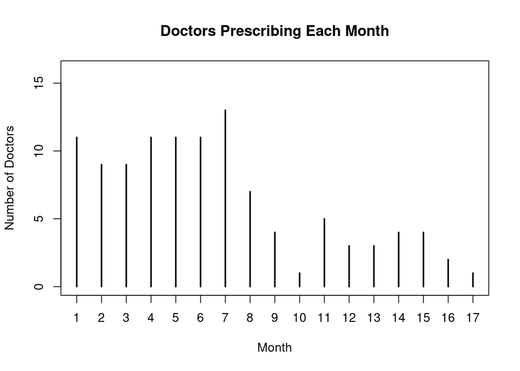

```r
plot(table(ckm_nodes), main = 'Doctors Prescribing Each Month',
     xlab = 'Month', ylab = 'Number of Doctors')
```

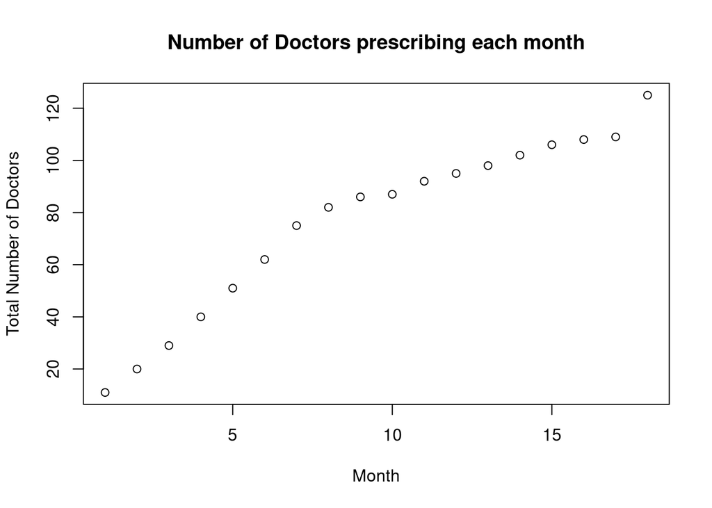

```r
plot(cumsum(table(ckm_nodes)), main = 'Number of Doctors prescribing each month',
     xlab = 'Month', ylab = 'Total Number of Doctors')
```

##### Problem 4. (10 points)

Adopted already or not yet?

1. Create a Boolean vector which indicates, for each doctor, whether they had begun prescribing tetracycline by month 2. Convert it to a vector of index numbers. There should be twenty such doctors.
2. Create a Boolean vector which indicates, for each doctor, whether they began prescribing tetracycline after month 14, or never prescribed it. Convert it to a vector of index numbers. There should be twenty-three such doctors.

##### Solution

Type your answer here

```r
ckm_nodes <= 2
```

```
##   [1]  TRUE FALSE FALSE FALSE FALSE FALSE FALSE FALSE FALSE  TRUE FALSE FALSE
##  [13]  TRUE FALSE FALSE FALSE FALSE FALSE FALSE  TRUE FALSE FALSE FALSE FALSE
##  [25] FALSE FALSE  TRUE FALSE FALSE FALSE FALSE FALSE FALSE FALSE FALSE FALSE
##  [37] FALSE FALSE FALSE FALSE FALSE FALSE FALSE FALSE  TRUE FALSE FALSE  TRUE
##  [49] FALSE FALSE FALSE FALSE FALSE FALSE  TRUE  TRUE FALSE FALSE FALSE FALSE
##  [61] FALSE FALSE  TRUE FALSE FALSE  TRUE FALSE FALSE FALSE  TRUE  TRUE FALSE
##  [73]  TRUE  TRUE  TRUE  TRUE FALSE FALSE FALSE FALSE  TRUE FALSE FALSE FALSE
##  [85] FALSE FALSE  TRUE FALSE FALSE FALSE FALSE FALSE FALSE FALSE FALSE FALSE
##  [97] FALSE FALSE FALSE FALSE FALSE FALSE FALSE FALSE FALSE FALSE  TRUE FALSE
## [109] FALSE FALSE FALSE FALSE FALSE FALSE FALSE FALSE FALSE FALSE FALSE FALSE
## [121] FALSE FALSE FALSE FALSE FALSE
```

```r
twomonths = which(ckm_nodes <= 2)
length(twomonths)
```

```
## [1] 20
```

```r
ckm_nodes > 14 | is.infinite(ckm_nodes)
```

```
##   [1] FALSE FALSE FALSE FALSE FALSE FALSE  TRUE FALSE FALSE FALSE FALSE FALSE
##  [13] FALSE  TRUE FALSE  TRUE  TRUE FALSE FALSE FALSE FALSE FALSE FALSE FALSE
##  [25] FALSE FALSE FALSE FALSE FALSE  TRUE FALSE FALSE FALSE FALSE FALSE FALSE
##  [37] FALSE FALSE  TRUE FALSE FALSE  TRUE FALSE FALSE FALSE FALSE FALSE FALSE
##  [49] FALSE  TRUE FALSE  TRUE FALSE FALSE FALSE FALSE FALSE FALSE FALSE FALSE
##  [61] FALSE  TRUE FALSE FALSE FALSE FALSE  TRUE FALSE FALSE FALSE FALSE FALSE
##  [73] FALSE FALSE FALSE FALSE FALSE FALSE  TRUE FALSE FALSE  TRUE FALSE FALSE
##  [85]  TRUE FALSE FALSE  TRUE  TRUE FALSE  TRUE FALSE FALSE  TRUE FALSE  TRUE
##  [97]  TRUE FALSE FALSE FALSE FALSE FALSE FALSE FALSE FALSE FALSE FALSE  TRUE
## [109]  TRUE FALSE FALSE FALSE FALSE FALSE FALSE FALSE FALSE FALSE FALSE FALSE
## [121] FALSE FALSE FALSE FALSE  TRUE
```

```r
fourteenmonths = which(ckm_nodes > 14 | is.infinite(ckm_nodes))
length(fourteenmonths)
```

```
## [1] 23
```

# Part II

##### Problem 5. (10 points)

The file `ckm_network.dat` contains a binary matrix; the entry in row $i$, column $j$ is 1 if doctor number $i$ said that doctor $j$ was a friend or close professional contact, and 0 otherwise. Load the file into R as `ckm_network` (Note that this is `.dat` file. You need to use `read.table()`), and verify that gives you a square matrix which contains only 0s and 1s, and that it has 246 rows and columns. Drop the rows and columns corresponding to doctors with missing adoption_date values. Check that the result has 125 rows and columns. Use this reduced matrix, and its row and column numbers, for the rest of the lab.

##### Solution

Type your answer here

```r
ckm_network = as.matrix(read.table("ckm_network.dat"))
sum(ckm_network > 1)
```

```
## [1] 0
```

```r
nrow(ckm_network)
```

```
## [1] 246
```

```r
ncol(ckm_network)
```

```
## [1] 246
```

```r
ckm_nodes <- read.csv("ckm_nodes.csv")
non_na_indices <- which(!is.na(ckm_nodes$adoption_date))
ckm_network <- ckm_network[non_na_indices, non_na_indices]
dim(ckm_network)
```

```
## [1] 125 125
```

##### Problem 6. (10 points)

Create a vector which stores the number of contacts each doctor has. Do not use a loop. Check that doctor number 41 had 3 contacts. Hint: You could do this using `apply()`, but you can also do it in one line with a single function.

##### Solution

Type your answer here

```r
rowSums(ckm_network)[41]
```

```
## [1] 3
```

##### Problem 7. (10 points)

Counting Peer Pressure

##### Solution

Type your answer here

```r
contact = ckm_network[37, ] == 1
prescribe = ckm_nodes$adoption_date <= 5
both = contact & prescribe
sum(both, na.rm = TRUE)
```

```
## [1] 4
```

```r
sum(both, na.rm = TRUE)/sum(contact)
```

```
## [1] 0.8
```

Behind the scenes: The original study was published as James Coleman, Elihu Katz and Herbert Menzel, “The Diffusion of an Innovation Among Physicians” Sociometry 20 (1957): 253–270. The files used here are taken from [http://moreno.ss.uci.edu/data.html#ckm] with some formatting changes. CKM actually measured three types of link among the doctors — friendship, general discussion, and asking for medical advice. To keep things simple, we are combining all three types of tie, and treating them as symmetric.